# Statistical Methods

Multiple Regression / Partial Effects

Fall 2025 | Course PSYC 790  
Jeffrey M. Girard | Lecture 10b

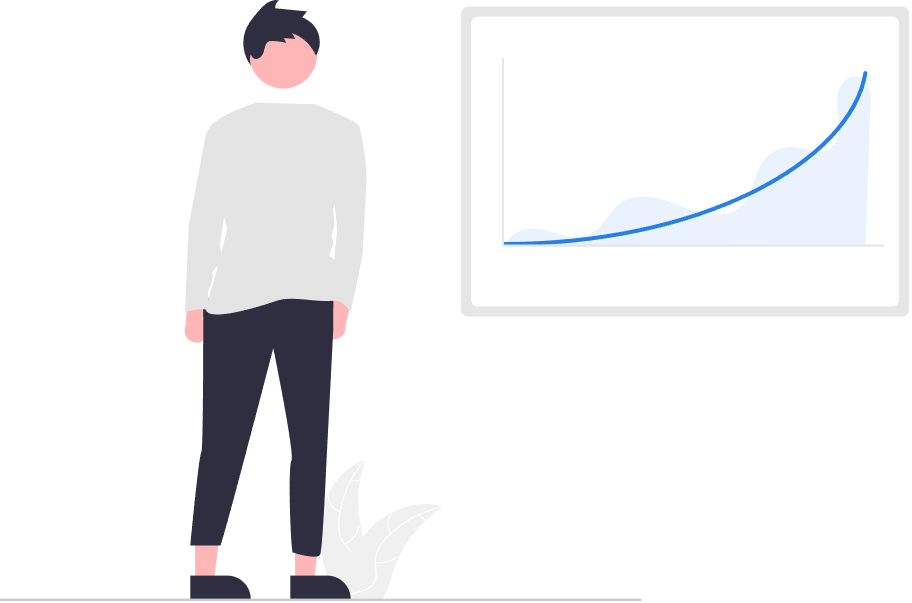

# Shared Variance

## Multiple regression

We often predict outcome variables using multiple predictors

1. This will usually yield better predictions and higher $R^2$
2. It will also let us isolate the predictors’ unique contributions
   - When predictors are correlated, they have redundancy
- *Example:* Predict salary from productivity and seniority
  - Having more pubs and more years both increase salary
  - However, these predictors are positively correlated
  - What is the *unique* contribution of each predictor?

## Multiple regression

- Let’s say we want to predict $y$ from $x_1$ and $x_2$
- We can extend our regression equation with another slope

$$\hat{y} = b_0 + b_1x_1 + b_2x_2$$

- $b_1$ is related to the correlation between $x_1$ and $y$
- $b_2$ is related to the correlation between $x_2$ and $y$
- We must account for any correlation between $x_1$ and $x_2$!

## Two Types of Effects

Zero-order effects

- Fit a separate simple regression model for each predictor

$$\text{M1: }\hat{y} = b_0 + b_1x_1 \qquad\quad \text{M2: }\hat{y} = b_0 + b_1x_2$$

- Interpretation of the $b_1$ slope from $\text{M1}$:  
  the *total* relationship between $x_1$ and $y$ (ignoring $x_2$)
- Interpretation of the $b_1$ slope from $\text{M2}$:  
  the *total* relationship between $x_2$ and $y$ (ignoring $x_1$)

## Two Types of Effects

Partial effects

- Fit a single multiple regression model with all predictors:

$$\text{M3: }\hat{y} = b_0 + b_1x_1 + b_2x_2$$

- Interpretation of the $b_1$ slope from $\text{M3}$:  
  the *unique* relationship between $x_1$ and $y$ (controlling $x_2$)
- Interpretation of the $b_2$ slope from $\text{M3}$:  
  the *unique* relationship between $x_2$ and $y$ (controlling $x_1$)

## Controlling predictors

- What does it mean to statistically “control” (for) a predictor?
- **What is the relationship between $x_1$ and $y$ if we hold $x_2$ at a constant value?** *e.g., What is the salary difference between prof A (10 pubs, 10 years) and prof B (10 pubs, 11 years)?*
- **If we already know $x_2$, how much does learning $x_1$ change our prediction of $y$?** *e.g., how much does learning that prof C has 20 pubs change our prediction of their salary if we already knew they have 15 years of seniority?*

## Venn diagram for simple regression

$$y_i = b_0 + b_1x_i + e_i$$

Each oval is one variable’s **variance**

Two oval’s overlap is their **covariance**

a is the variance in $x$ unrelated to $y$

b is the variance shared by $x$ and $y$

e is the variance in $y$ unrelated to $x$

$b_1$ represents b

$R^2$ represents b / (b + e)

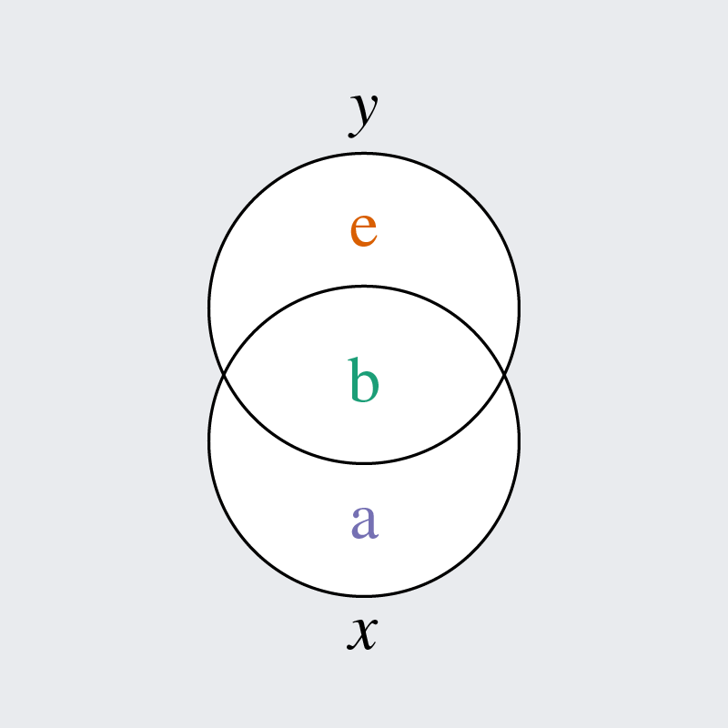

## Venn diagram for two predictors

$$y_i = b_0 + b_1x_{1i} + b_2x_{2i} + e_i$$

a is the var in $x_1$ unrelated to $y$ or $x_2$

b is the var shared by $x1$ and $y$ (not $x_2$)

c is the var shared by $x_1$, $x_2$, and $y$

d is the var shared by $x_1$ and $x_2$ (not $y$)

e is the var in $y$ unrelated to $x_1$ or $x_2$

f is the var shared by $x_2$ and $y$ (not $x_1$)

g is the var in $x_2$ unrelated to $x_1$ or $y$

## Zero-order effect of $x_1$

$$y_i = b_0 + b_1x_{1i} + e_i$$

If we regress $y$ on $x_1$ only, we get the zero-order (i.e., total) effect of $x_1$

$b_1$ represents b + c

$e_i$ represents e + f

$R^2$ represents (b + c) / (b + c + e + f)

## Zero-order effect of $x_2$

$$y_i = b_0 + b_1x_{2i} + e_i$$

If we regress $y$ on $x_2$ only, we get the zero-order (i.e., total) effect of $x_2$

$b_1$ represents c + f

$e_i$ represents e + b

$R^2$ represents (c + f) / (c + f + e + b)

## Partial effects of $x_1$ and $x_2$

$$y_i = b_0 + b_1x_{1i} + b_2x_{2i} + e_i$$

If we regress $y$ on both $x_1$ and $x_2$, we get their partial (i.e., unique) effects

$b_1$ represents b only

$b_2$ represents f only

$e_i$ represents e only

$R^2$ represents (b + c + f) / (b + c + f + e)

c is included in $R^2$ but neither slope

## Collinearity

$$y_i = b_0 + b_1x_{1i} + b_2x_{2i} + e_i$$

If $x_1$ and $x_2$ are highly correlated, then c will be large and b and f may be small

Small slopes may lead you to conclude that $x_1$ and $x_2$ are not related to $y$

But this isn’t quite right… it’s just that they don’t *uniquely* explain $y$ (rather, it is their overlap/shared variance that does)

So check zero-order *and* partial effects

We will return to talk about collinearity more in a future lecture.

# Multiple Regression

## Standardized partial effects

- The relationships are clearer if we start with *standardized* slopes first

$$\hat{y}_i^{(z)} = \beta_1x_{1i}^{(z)} + \beta_2x_{2i}^{(z)}$$

- We want to find the $\beta$ values that minimize the squared residuals

$$\beta_1 = \frac{r(y,x_1)-r(y,x_2)r(x_1,x_2)}{1-r(x_1,x_2)^2}$$

$$\beta_2 = \frac{r(y,x_2)-r(y,x_1)r(x_1,x_2)}{1-r(x_1,x_2)^2}$$

- We start with the zero-order correlation we want to partialize (i.e., that between the predictor and outcome) and then remove the redundant/shared variance

Note that we omit $\beta_0$ because it is always zero.

## Unstandardized partial effects

- To unstandardize the partial effects, we multiply by SD ratios

$$b_1 = \beta_1\frac{s_y}{s_{x1}}$$

$$b_2 = \beta_2\frac{s_y}{s_{x2}}$$

- To calculate the unstandardized intercept, we can do…

$$b_0 = \bar{y} - b_1\bar{x}_1 - b_2\bar{x}_2$$

## Example data

```r
library(tidyverse)
library(easystats)
yearspubs <- read_csv("yearspubs.csv")
yearspubs
## # A tibble: 62 × 5
##    yrs_since n_pubs sex    n_cites salary
##        <dbl>  <dbl> <chr>    <dbl>  <dbl>
##  1         3     18 female      50  21876
##  2         6      3 female      26  54511
##  3         3      2 female      50  53425
##  4         8     17 male        34  61863
##  5         9     11 female      41  52926
##  6         6      6 male        37  47034
##  7        16     38 male        48  66432
##  8        10     48 male        56  61100
##  9         2      9 male        19  41934
## 10         5     22 male        29  97454
## # ℹ 52 more rows
```

## Zero-order correlations

```r
y <- yearspubs$salary
x1 <- yearspubs$n_pubs
x2 <- yearspubs$yrs_since

r_y1 <- cor(y, x1)
r_y1
## [1] 0.4333142

r_y2 <- cor(y, x2)
r_y2
## [1] 0.5053046

r_12 <- cor(x1, x2)
r_12
## [1] 0.6543128
```

## Zero-order effects

```r
fit1 <- lm(salary ~ n_pubs, data = yearspubs)
fit2 <- lm(salary ~ yrs_since, data = yearspubs)

compare_parameters(fit1, fit2)
## Parameter    |                          fit1 |                          fit2
## ----------------------------------------------------------------------------
## (Intercept)  | 48565.76 (44098.32, 53033.21) | 45625.47 (40678.49, 50572.46)
## n pubs       |   364.82 (  168.87,   560.76) |
## yrs since    |                               |  1400.94 (  783.12,  2018.77)
## ----------------------------------------------------------------------------
## Observations |                            62 |                            62

compare_parameters(fit1, fit2, standardize = "refit")
## Parameter    |                   fit1 |                   fit2
## --------------------------------------------------------------
## (Intercept)  | 2.65e-16 (-0.23, 0.23) | 2.11e-16 (-0.22, 0.22)
## n pubs       |     0.43 ( 0.20, 0.67) |
## yrs since    |                        |     0.51 ( 0.28, 0.73)
## --------------------------------------------------------------
## Observations |                     62 |                     62
```

## Partial effects

```r
fit3 <- lm(salary ~ n_pubs + yrs_since, data = yearspubs)

model_parameters(fit3)
## Parameter   | Coefficient |      SE |               95% CI | t(59) |      p
## ---------------------------------------------------------------------------
## (Intercept) |    45113.71 | 2498.17 | [40114.89, 50112.53] | 18.06 | < .001
## n pubs      |      151.18 |  123.52 | [  -95.98,   398.34] |  1.22 | 0.226
## yrs since   |     1075.21 |  406.75 | [  261.30,  1889.11] |  2.64 | 0.010

model_parameters(fit3, standardize = "refit")
## Parameter   | Coefficient |   SE |        95% CI |    t(59) |      p
## --------------------------------------------------------------------
## (Intercept) |    2.20e-16 | 0.11 | [-0.22, 0.22] | 2.00e-15 | > .999
## n pubs      |        0.18 | 0.15 | [-0.11, 0.47] |     1.22 | 0.226
## yrs since   |        0.39 | 0.15 | [ 0.09, 0.68] |     2.64 | 0.010
```

## Coefficient interpretation

> The intercept is the estimated salary for a professor with zero years since PhD and zero publications: $45113.71, 95% CI: [40114.89, 50112.53].

> The partial effect of *number of publications* was not significantly different from zero at $151.18. When controlling for the number of years since PhD, each additional publication was associated with an additional −$95.98 to $398.34.

> The partial effect of *years since PhD* was significantly different from zero at $1075.21. Thus, when controlling for number of publications, each additional year since PhD was associated with an additional $261.30 to $1889.11.

## Coefficient comparison

Note that the partial effects were *smaller* than the zero-order effects

- The slope for `n_pubs` went from 364.82 (*p*<.001) to 151.18 (*p*=.226)
- The slope for `yrs_since` went from 1400.94 (*p*<.001) to 1075.21 (*p*=.010)

This suggests that the *shared variance* is doing a lot of work (especially for `n_pubs`)

- When we remove this shared variance, the partial effects become smaller
- This is a very common pattern for correlated predictors in a multiple regression
- $x_1$ and $x_2$ are thus “partially redundant” due to their shared variance
- However, this is not *always* the pattern (e.g., in [suppression effects](https://en.wikipedia.org/wiki/Suppressor_variable))

## Explained Variance

```r
compare_performance(fit1, fit2, fit3, metrics = "R2")
## # Comparison of Model Performance Indices
##
## Name | Model |    R2
## --------------------
## fit1 |    lm | 0.188
## fit2 |    lm | 0.255
## fit3 |    lm | 0.274
```

Moving from model `fit1` to `fit3` (i.e., learning `yrs_since`) improves $R^2$ more $(\Delta R^2=.086)$ than moving from model `fit2` to `fit3` (i.e., learning `n_pubs`) does $(\Delta R^2=.019)$.

## Plotting marginal effects

```r
# install.packages(c("ggeffects", "effects"))
library(ggeffects)
```

```r
plot(predict_response(
  model = fit3,
  terms = "n_pubs"
))
```

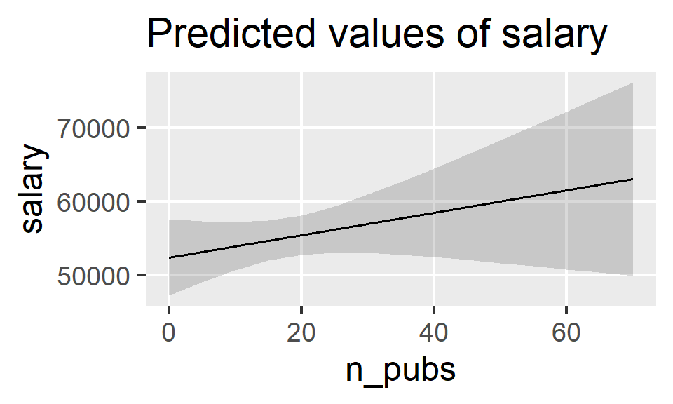

```r
plot(predict_response(fit3, "n_pubs")) + mytheme(18)
```

```r
plot(predict_response(
  model = fit3,
  terms = "yrs_since"
))
```

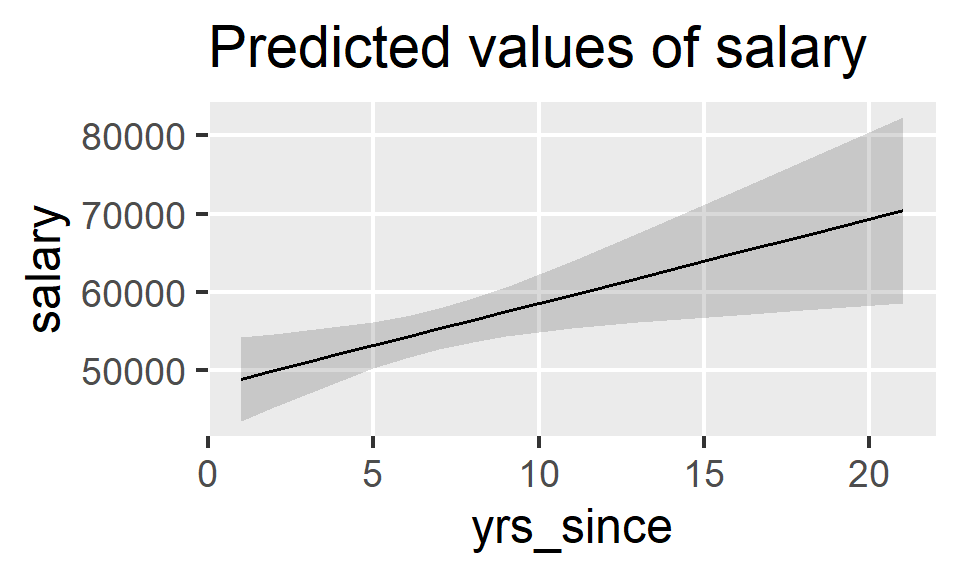

```r
plot(predict_response(fit3, "yrs_since")) + mytheme(18)
```

Note these plots hold the other predictors at their average value.

## Plotting marginal effects

```r
plot(predict_response(
  model = fit3,
  terms = c(
    "n_pubs",
    "yrs_since"
  )
))
```

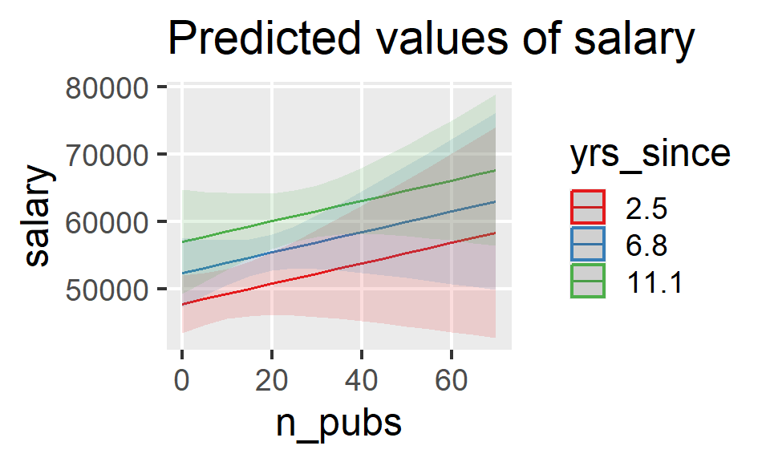

```r
plot(predict_response(fit3, c("n_pubs", "yrs_since"))) + mytheme(18)
```

```r
plot(predict_response(
  model = fit3,
  terms = c(
    "yrs_since",
    "n_pubs"
  )
))
```

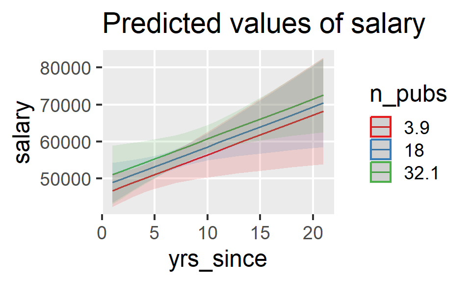

```r
plot(predict_response(fit3, c("yrs_since", "n_pubs"))) + mytheme(18)
```

# Many Predictors

## Extended regression equation

- If we have $k$ predictors, we can add a slope for each one

$$\hat{y} = b_0 + b_1x_1 + b_2x_2 + \cdots + b_kx_k$$

- We still find $b$ values that minimize the squared residuals
- The intercept is the value of $\hat{y}$ when *all* predictors equal 0
- Each slope is partial (i.e., controls for *all* other predictors)
- We can combine continuous and categorical predictors!

## Example zero-order effects

```r
m_pub <- lm(salary ~ n_pubs, data = yearspubs)
m_yrs <- lm(salary ~ yrs_since, data = yearspubs)
m_sex <- lm(salary ~ sex, data = yearspubs)
m_cit <- lm(salary ~ n_cites, data = yearspubs)

compare_parameters(m_pub, m_yrs, m_sex, m_cit, standardize = "refit")
## Parameter    |                  m_pub |                  m_yrs
## --------------------------------------------------------------
## (Intercept)  | 2.65e-16 (-0.23, 0.23) | 2.11e-16 (-0.22, 0.22)
## n pubs       |     0.43 ( 0.20, 0.67) |
## yrs since    |                        |     0.51 ( 0.28, 0.73)
## sex [male]   |                        |
## n cites      |                        |
## --------------------------------------------------------------
## Observations |                     62 |                     62
##
## Parameter    |               m_sex |                  m_cit
## -----------------------------------------------------------
## (Intercept)  | -0.31 (-0.68, 0.07) | 2.87e-16 (-0.24, 0.24)
## n pubs       |                     |
## yrs since    |                     |
## sex [male]   |  0.54 ( 0.05, 1.04) |
## n cites      |                     |     0.38 ( 0.14, 0.62)
## -----------------------------------------------------------
## Observations |                  62 |                     62
```

- All zero-order effects are significant (we can tell this from above because none of the slopes’ 95% CIs contain zero)

## Example partial effects

```r
m_all <- lm(salary ~ n_pubs + yrs_since + sex + n_cites, data = yearspubs)
model_parameters(m_all, standardize = "refit")
## Parameter   | Coefficient |   SE |        95% CI | t(57) |     p
## ----------------------------------------------------------------
## (Intercept) |       -0.17 | 0.17 | [-0.50, 0.16] | -1.05 | 0.297
## n pubs      |        0.14 | 0.14 | [-0.15, 0.43] |  0.95 | 0.345
## yrs since   |        0.31 | 0.15 | [ 0.01, 0.61] |  2.10 | 0.040
## sex [male]  |        0.31 | 0.22 | [-0.14, 0.75] |  1.38 | 0.172
## n cites     |        0.20 | 0.12 | [-0.04, 0.43] |  1.66 | 0.103
```

- “The partial effect of *years since PhD* was significant (*p*=.040). Thus, while controlling for sex and the number of publications and citations, each SD increase in years since PhD was associated with a 0.31 SD increase in salary.”

## Example effect sizes

```r
compare_performance(m_pub, m_yrs, m_sex, m_cit, m_all,
                    metrics = c("R2", "R2_adj"))
## # Comparison of Model Performance Indices
##
## Name  | Model |    R2 | R2 (adj.)
## ---------------------------------
## m_pub |    lm | 0.188 |     0.174
## m_yrs |    lm | 0.255 |     0.243
## m_sex |    lm | 0.074 |     0.058
## m_cit |    lm | 0.145 |     0.131
## m_all |    lm | 0.333 |     0.286
```

- “The linear model predicting salary from years since PhD, number of publications, sex, and number of citations explained one-third of the variance in salary (R²=.333, Adjusted R²=.286).”

## Striking a balance

- Covariates are predictors we only want to control
  - The linear model does not treat them differently
- In some fields, it is common to include many covariates
- Relevant predictors should be included but don’t go too far
  - Adding predictors can *decrease your power*
  - Adding predictors can *lead to collinearity*
  - Adding predictors can *change your interpretation*
- Think carefully about what to include vs. exclude

There are optional readings this week on this topic.